# Session 03: What is political polarization?

Tristan Muno

October 14, 2026

## What comes to mind?

**What comes to mind when you hear the word “polarization”?**

Go to **menti.com** and enter **2832 7219**

## Session 03 goals

By the end of today, you will be able to:

1. Distinguish elite from mass polarization, and ideological divergence from issue alignment.
2. Explain why two authors can disagree about whether a public is polarized without disagreeing about any fact.
3. Identify which concept of polarization a given empirical claim depends on.

## Today

1. **The concept**
   - A word borrowed from physics, and the meanings it picked up
2. **The debate**
   - Is the American public polarized? A 2008 exchange in the *Journal of Politics*
3. **Abramowitz and Saunders (2008)**
   - “Is polarization a myth?”
4. **Fiorina, Abrams and Pope (2008)**
   - “Misconceptions and misreadings”
5. **What were they disagreeing about?**
   - Pair task and discussion
6. **Wrap-up**

# The concept

## Borrowed from physics

- In physics, polarization is the *orientation* of a wave
- The original meaning is alignment, orientation, separation
- Nothing about conflict or hostility. Social science supplied that.

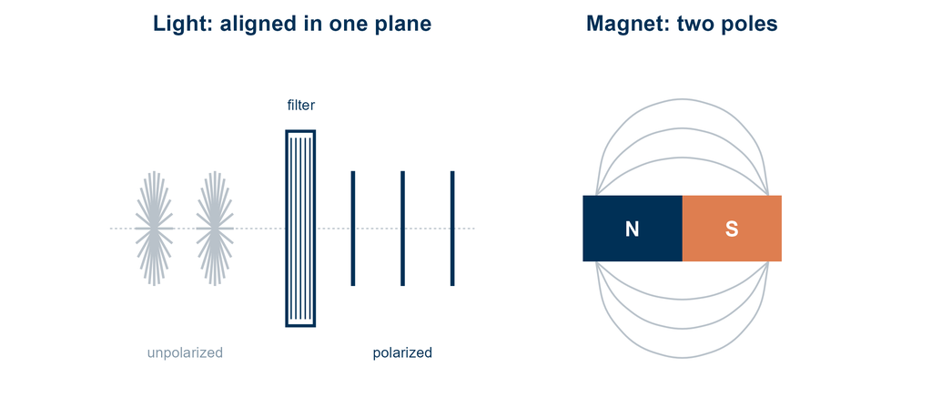

Figure 1: Two physical meanings of polarization. Light passing a filter ends up aligned in one plane, and a magnet separates charge towards two poles. Neither involves conflict.

## A family of concepts

- Broadest usage: alignment, separation, sorting, divergence
- At least four mathematically distinct things share the name
- They can move in **opposite directions in the same data**

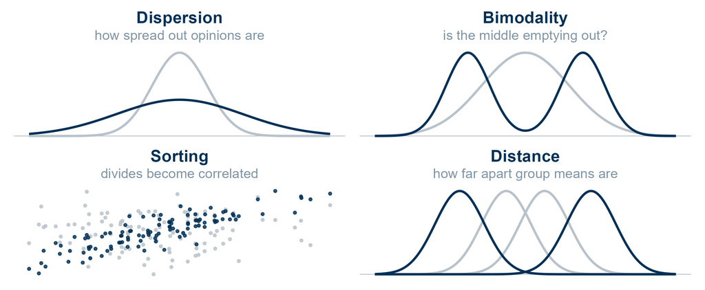

Figure 2: Four meanings of polarization, grey before and navy after. Dispersion is how spread out opinions are, bimodality is whether the middle empties, sorting is whether two divides become correlated, and distance is how far apart group means are.

## Three further axes

- Bipolar vs multipolar: nothing requires two camps
- State vs process: a snapshot vs a trend
- Object vs target: who is polarized against whom?

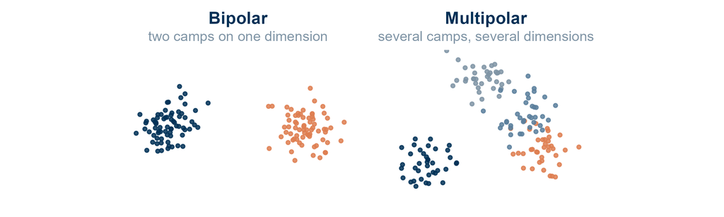

Figure 3: Bipolar and multipolar configurations. On the left, two camps on one dimension. On the right, several camps spread over several dimensions.

## Elite versus mass

- **Elites** (legislators, activists): divergence since the 1970s is not disputed (Fiorina et al. 2008)
- **The mass public**: does the electorate follow its elites?
- Two further distinctions sit inside that question
  - *Ideological divergence*: people move apart on issues, towards the extremes
  - *Issue alignment*: positions bundle together, and with party, without anyone moving

# The debate

## Is the public polarized?

- After 2000 and 2004: red states vs blue states, a “culture war” narrative
- *Culture War? The Myth of a Polarized America* (Fiorina et al. 2006): the public is **closely** but not **deeply** divided
- *Journal of Politics* 70 (2), 2008, critique and reply back to back
  - Abramowitz and Saunders (2008): “Is polarization a myth?”
  - Fiorina et al. (2008): “Misconceptions and misreadings”
- Same data, same decades, opposite verdicts

# Abramowitz and Saunders (2008)

## Introduction

- **Puzzle:** Fiorina says today’s voters look like the barely ideological public Converse (2006) described for the 1950s
- But much has changed since then
  - Share with some college education: 19% in 1956, 61% in 2004
  - Party elites have moved apart for decades
- **Question:** is mass polarization a myth?
- They test five of Fiorina’s claims: moderation, partisan and geographic polarization, social cleavages, and voter engagement

## Theory

- **Education and elite cues:** a more educated public, watching polarized elites, should think more ideologically
- **The engaged:** polarization should be deepest among the interested, informed and active, “whose opinions matter most to candidates and officeholders”
- **Mobilization:** polarization raises the stakes of an election, so it should *energize* voters, not turn them off

## Research design

- **Data:** American National Election Studies 1972 to 2004, 2004 National Exit Poll
- **Ideological consistency:** seven issues, each collapsed to liberal, moderate or conservative
  - Score = |number of liberal positions minus number of conservative positions|
  - A 16-item scale for 2004, recoded to 11 points
- **Engagement:** interest, knowledge and participation, split into thirds
- **Partisan polarization:** correlation of party identification with ideology over time
- **Geography and religion:** red vs blue state voters, logit of the Bush vote on religiosity

## Results: consistency

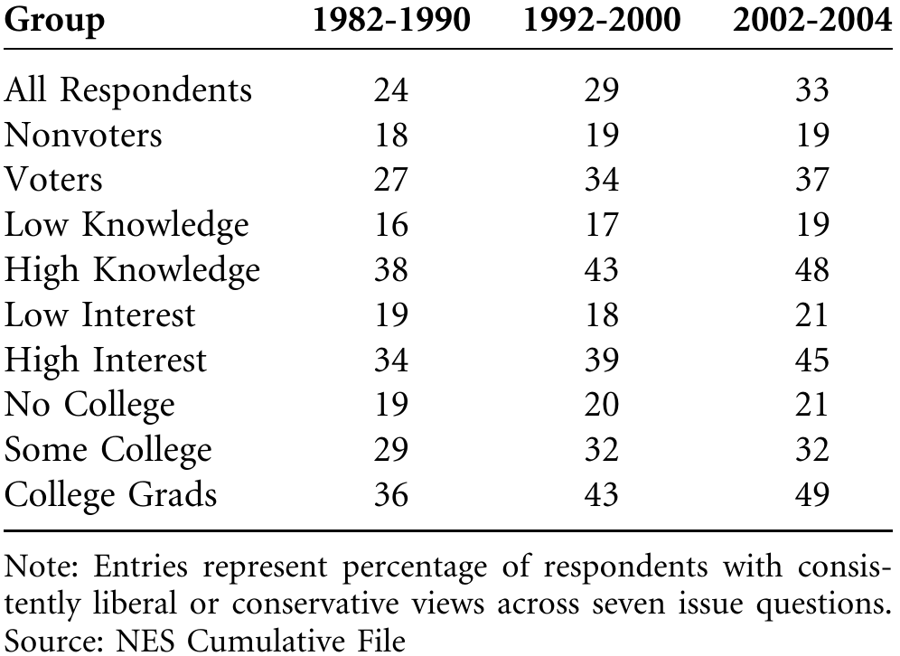

Figure 4: Share of respondents holding consistently liberal or consistently conservative positions across seven issue questions, by decade and by group. It rises for every engaged group and stays flat for nonvoters. *Source:* Abramowitz and Saunders (2008), Table 1.

- The average correlation between the seven items rises from .20 to .26 to .32

## Results: the engaged

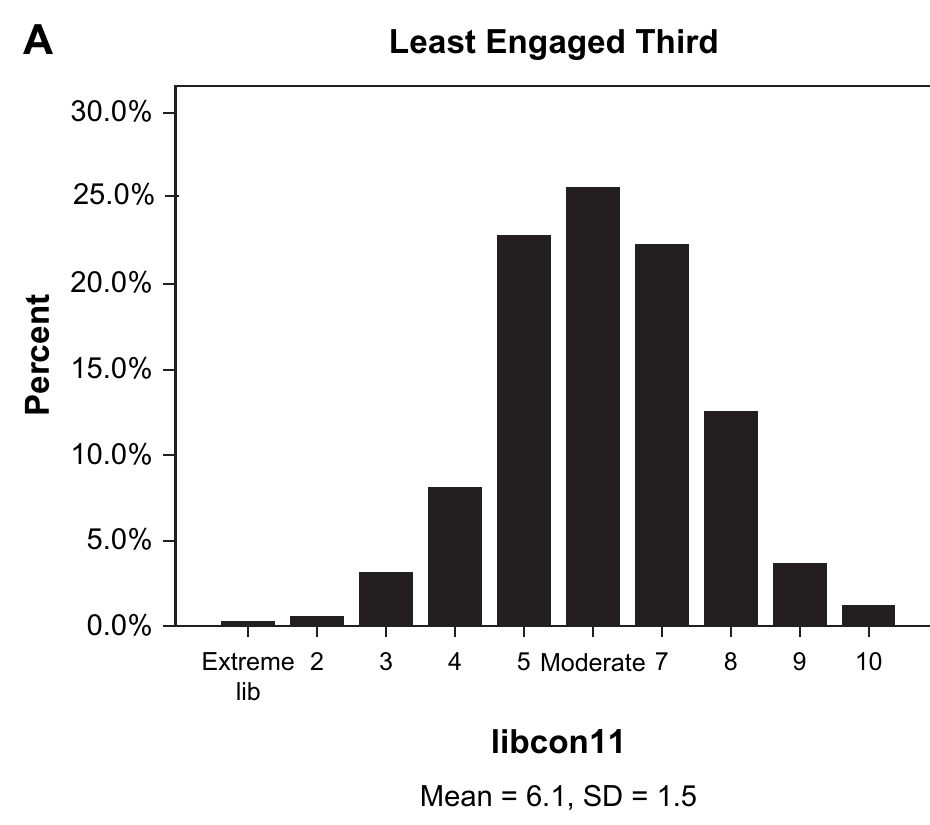

Figure 5: The least engaged third of 2004 NES respondents on an 11-point liberal-conservative policy scale, clustered on the moderate positions. Mean 6.1, SD 1.5. *Source:* Abramowitz and Saunders (2008), Figure 1, panel A.

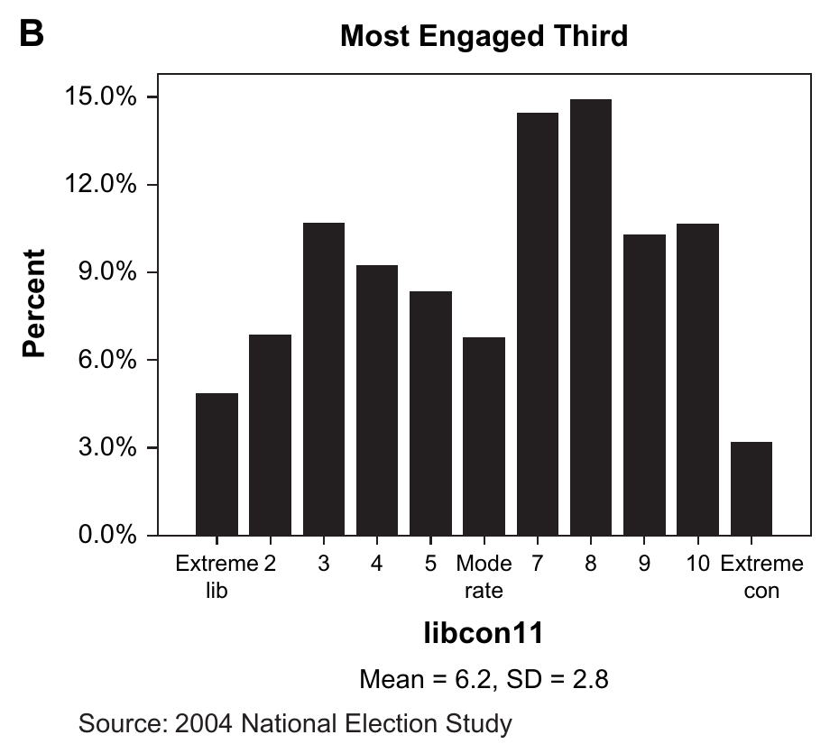

Figure 6: The most engaged third on the same scale, spread towards both ends with a dip at the middle. Mean 6.2, SD 2.8. *Source:* Abramowitz and Saunders (2008), Figure 1, panel B.

- Same mean, nearly double the spread. The engaged third is 37% of respondents and close to half of all voters.

## Results: sorting

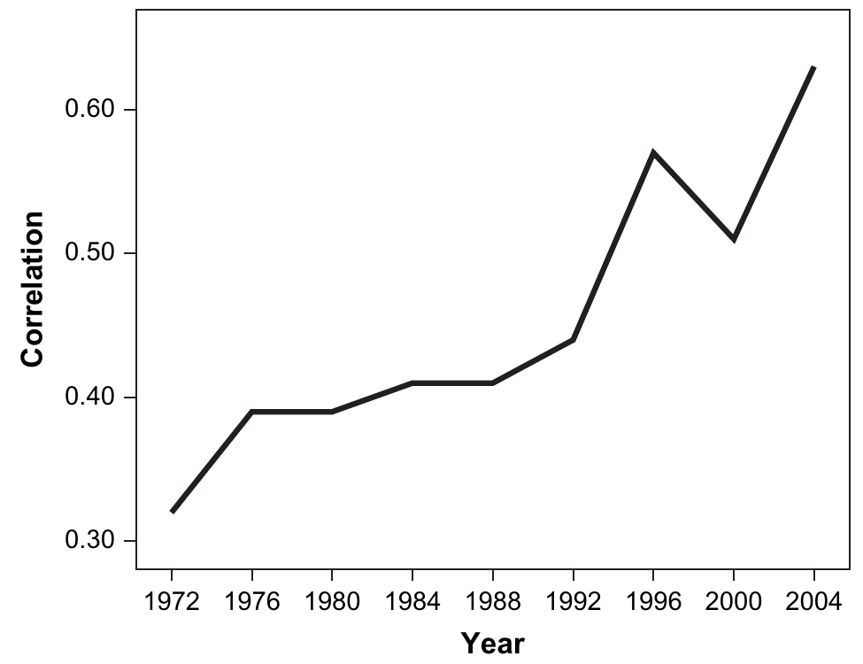

Figure 7: Correlation of party identification with liberal-conservative identification in the NES, 1972 to 2004. It rises from .32 to .63, most steeply after 1992. *Source:* Abramowitz and Saunders (2008), Figure 3.

- Among the engaged the same correlation runs from .47 to **.77**, and the gap between the parties’ mean ideology doubles

## Results: geography

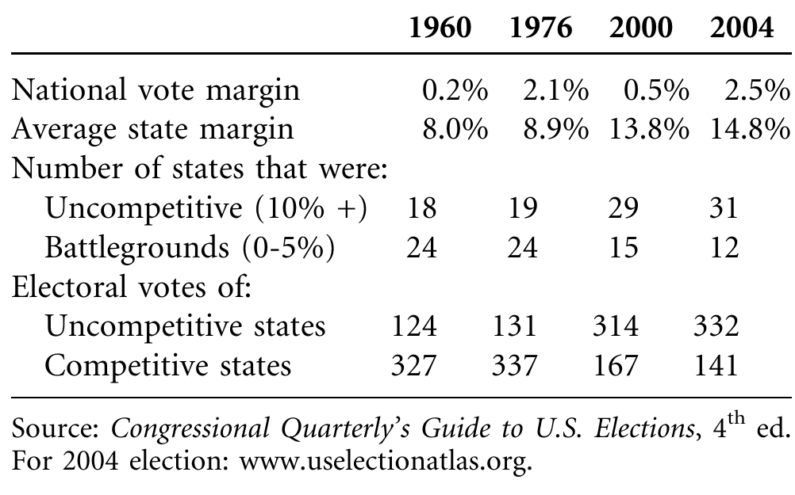

Figure 8: Competitiveness of four closely contested presidential elections. The national margin stays small, while the average state margin nearly doubles and the number of battleground states halves. *Source:* Abramowitz and Saunders (2008), Table 5.

## Results: other evidence

- **Religion:** among white voters, religiosity predicts the Bush vote better than any other social characteristic
  - P(Bush vote) .34 for the least religious, .81 for the most religious
- **Engagement in 2004:** turnout 54% to 61%, persuasion attempts 32% to 48%
  - Voters feeling strongly about Bush, either way, were the most likely to vote and campaign

## Conclusion

- Polarization is **not** just an elite phenomenon
- The centre is held by the least interested, informed and active
- Elite divisions “reflect real divisions within the American electorate”
- Polarization **energizes** the electorate rather than turning it off

> “We have met the enemy and he is us” (Abramowitz and Saunders 2008, quoting Pogo)

# Fiorina, Abrams and Pope (2008)

## Introduction

- A point-by-point reply to the five criticisms
- **Before the reply, a rule about evidence:**
  - Votes, election returns and approval ratings “can not be used as evidence of polarization, for or against”
- Everything else follows from that rule and from one definition

## Theory

- **Polarization** = movement from the centre towards the extremes, so the test is rising **bimodality**
- **Sorting** is something else: party groups grow more distinct while the overall distribution stays put
- Centrist voters register polarized **choices** when the candidates polarize, without moving themselves
- So a changed relationship in the data may sit on the candidates’ side, not the voters’

## Research design

- **Raw distributions** instead of recoded and aggregated indices
- Ideological self-placement in three surveys: NES, GSS and Gallup, 1970s to 2000s
- The same NES issue scales as A&S, compared position by position, 1984 vs 2004
- Pew Research Center: party differences on 40 items, 1987 to 2007
- Abortion positions of strong partisans in 2004

## Results: raw data

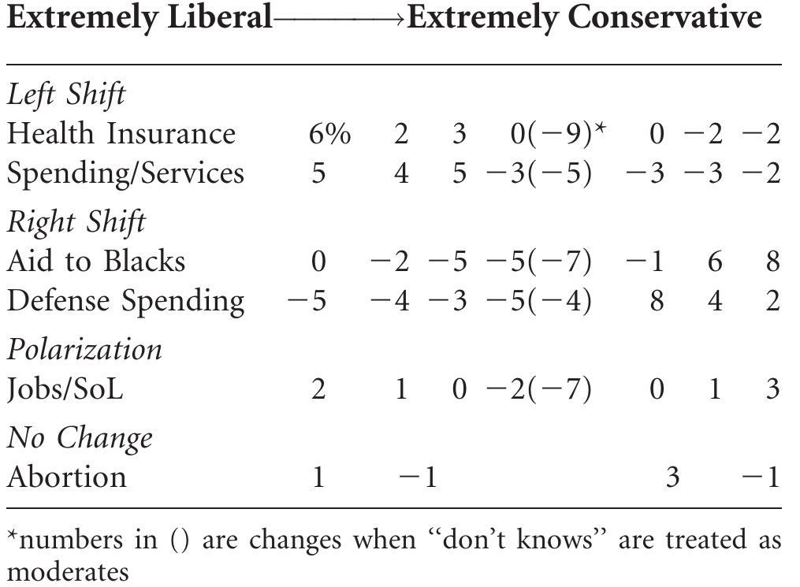

Figure 9: Percentage point change in each position of six NES issue scales between 1984 and 2004, from extremely liberal (left) to extremely conservative (right). Numbers in brackets treat “don’t knows” as moderates. *Source:* Fiorina et al. (2008), Table 1.

- Only jobs and standard of living loses its centre to **both** extremes

## Results: limited sorting

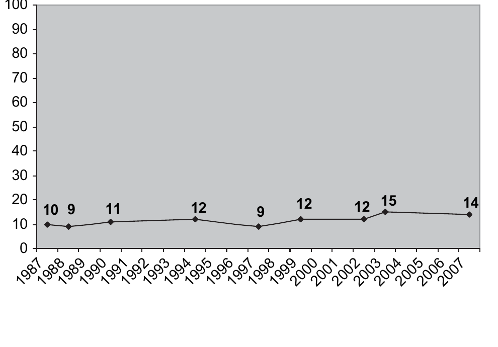

Figure 10: Average percentage point difference between Republican and Democratic identifiers on 40 political and social questions, 1987 to 2007. It grows from 10 to 14 points. *Source:* Fiorina et al. (2008), Figure 1, from Pew Research Center data.

- Party sorting “certainly has occurred”, but far less than among elites

## Results: the rest

- **Abortion, 2004:** a third of strong Democrats and two fifths of strong Republicans break with their party’s position
- **Red vs blue states:** majorities disagree on **one** NES issue, homosexual adoption
- **2004 turnout:** the parties’ ground game rather than polarization, with party contacts up 8 points
- **Religion vs class:** A&S attribute a claim to them that they say they never made

## Conclusion

- Without “multiple recodings and aggregations”, the A&S case “disappears”
- **Sorting yes, polarization no**
- Red-blue divides are a “misleading exaggeration”
- 2004 engagement rests on one election and ignores mobilization
- “No reason to revise the conclusions of *Culture War?*”

# What were they disagreeing about?

## Two definitions

> “adopting the common sense notion of polarization as a movement from the center toward the extremes, one searches in vain for evidence of increasing bimodality” (Fiorina et al. 2008)

> “the existence of polarization in a society does not just depend on the overall distribution of political attitudes among the public. It also depends on whether there are differences between the views of important subgroups” (Abramowitz and Saunders 2008)
- One asks about the **shape of a distribution**, the other about **differences between groups inside it**

## Pair task

For each claim, note what **evidence** each side uses and which **concept** from Figure 2 or the three axes it rests on.

1. “The public is more polarized than in the 1980s.”
2. “Democrats and Republicans are further apart.”
3. “The public is polarized where it counts.”
4. “Voters are divided: look at the red and blue map.”
5. “The data show it.”

Then decide: is the disagreement about a **definition**, a **measurement** or a **fact**?

## The mapping

Table 1: Five disputed claims in the 2008 exchange, the evidence each side uses for them, and the concept or measurement choice the disagreement turns on.

| Claim | A&S look at | FAP look at | What is at stake |
| --- | --- | --- | --- |
| The public is polarized | Consistency across issues, 24 to 33% | Each item’s raw distribution, the middle holds | Constraint vs bimodality |
| The parties are further apart | Party ID and ideology, r .32 to .63 | The same fact, called sorting | Sorting vs polarization |
| Polarized where it counts | The engaged third, SD 2.8 | The public as a whole | Which population |
| Voters are divided | Votes, approval, red vs blue states | Not evidence, it reflects the candidates | Choices vs positions |
| The data show it | Recoded items, don’t knows as moderates, an index | Raw position-by-position change | Measurement |

## Three kinds of dispute

- **Mostly definitional:** both accept that party sorting happened. They disagree about whether to call it polarization.
- **Partly measurement:** coding “don’t knows” as moderates and aggregating items into an index change the answer
- **A little substantive:** was 2004 turnout driven by polarization or by party mobilization? Does religion outweigh class?

**Important**

**“Is the public polarized?” has no answer until you say what you mean with “polarization”.** Two authors can read the same data and reach opposite verdicts, because they are measuring different concepts.

## Questions for the group

- If both sides accept that sorting happened, what exactly is left to disagree about?
- Is a public polarized if its engaged third is? Whose opinions should count?
- If votes cannot show polarization, what evidence could?
- Does any of this travel to a multiparty system like Germany’s?

# Wrap-up

## Recap: takeaways

- **Polarization is a family of concepts:** dispersion, bimodality, sorting, distance, plus three axes
- **Elites diverged** without dispute. The contested question is the mass public.
- **A&S** find rising consistency and sorting, deepest among the engaged
- **FAP** find a stable middle and call the rest sorting
- Most of the dispute is about **which concept** and **which population**, some about coding, little about facts

## Recap: learning goals

**Goal 1. Elite vs mass, divergence vs alignment**

- Elite polarization concerns office holders and activists, mass polarization the electorate
- Divergence means moving towards the extremes. Alignment means positions bundling together, and with party.

**Goal 2. Disagreeing without disagreeing about a fact**

- A&S and FAP largely agree on the facts, but attach the word to different concepts and populations

**Goal 3. Which concept a claim depends on**

- Ask what distribution changed, in whom, and whether it is positions or choices

## Next session

- **Session 04: What is affective polarization?**
- From where people *stand* to how they *feel* about the other side
- Core reading: Iyengar et al. (2012) and Iyengar and Westwood (2015)

## Before you go

- The term paper is **empirical**: it confronts a claim with data you analyse yourself
- It is **two things**: the written paper, and the code that reproduces its analysis
- **Any technology**, R, Python, Stata or anything else. Nothing is prescribed.
- What is required is that a result comes out of a **script that runs again**, not out of clicks nobody can retrace
- The detail is in the syllabus

**Note**

**Two voluntary platforms, neither needed to pass.** DataCamp gives you six months of premium access through the course group, for self-paced practice in R and data analysis. [Duolingo Math](https://www.duolingo.com/math) is there if you want to warm up the maths.

## References

Abramowitz, Alan I., and Kyle L. Saunders. 2008. “Is Polarization a Myth?” *The Journal of Politics* 70 (2): 542–55. https://doi.org/10.1017/S0022381608080493.

Converse, Philip E. 2006. “The Nature of Belief Systems in Mass Publics.” *Critical Review* 18: 1–74. https://doi.org/10.1080/08913810608443650.

Fiorina, Morris P., Samuel A. Abrams, and Jeremy C. Pope. 2008. “Polarization in the American Public: Misconceptions and Misreadings.” *The Journal of Politics* 70 (2): 556–60. https://doi.org/10.1017/S002238160808050X.

Fiorina, Morris P., Samuel J. Abrams, and Jeremy C. Pope. 2006. *Culture War? The Myth of a Polarized America*. 2nd ed. Pearson Longman.

Iyengar, Shanto, Gaurav Sood, and Yphtach Lelkes. 2012. “Affect, Not Ideology: A Social Identity Perspective on Polarization.” *Public Opinion Quarterly* 76 (3): 405–31. https://doi.org/10.1093/poq/nfs038.

Iyengar, Shanto, and Sean J. Westwood. 2015. “Fear and Loathing Across Party Lines: New Evidence on Group Polarization.” *American Journal of Political Science* 59 (3): 690–707. https://doi.org/10.1111/ajps.12152.